# Analysis of Lewis Replication Pilot Data & Analysis Plan for Official Data

Sarah Raposo

February 22, 2016

*Note:* this script is for data that has already gone through preprocessing

Loading packages and helper functions

```r
rm(list=ls())
library(rjson)
library(dplyr)
library(tidyr)
library(stringr)
library(splitstackshape)
library(ggplot2)

sem <- function(x) {sd(x, na.rm=TRUE) / sqrt(length(x))}
ci95 <- function(x) {sem(x) * 1.96}
theme_set(theme_bw())

## NA functions
na.mean <- function(x) {mean(x,na.rm=T)}
na.median <- function(x) {median(x,na.rm=T)}
na.sum <- function(x) {sum(x,na.rm=T)}
na.sd <- function(x) {sd(x,na.rm=T)}

## convert to number
to.n <- function(x) {
  as.numeric(as.character(x))
}

## get stars for significance testing
getstars <- function(x) {
  if (x > .1) {return("")}
  if (x < .001) {return("***")}
  if (x < .01) {return("**")}
  if (x < .05) {return("*")}
}
```

### Reading dataframe

```r
setwd("~/Desktop/sraposoProject/ignore/data")
d = read.csv("LewisReplication_PilotData_TidyClean.csv")
length(unique(d$workerid))
```

```
## [1] 7
```

```r
#str(d)
```

This dataset has 7 participants.

### Some minor preprocessing

Changing factor structure.

```r
d$conditionnum = as.numeric(d$condition)

table(d$edu)
```

```
##
## 1 2 3 4 5
## 1 1 1 3 1
```

```r
d$educat = factor(d$edu, labels = c("high school", "some college", "college degree", "some postbac", "professional degree"))
table(d$educat)
```

```
##
##         high school        some college      college degree
##                   1                   1                   1
##        some postbac professional degree
##                   3                   1
```

```r
table(d$income)
```

```
##
## 1 2 3 4 5
## 1 3 1 1 1
```

```r
d$incomecat = factor(d$income, labels = c("<$24,999", "$25-$49,999", "$50-$74,999", "$75-$99,999", "$100,000+"))
table(d$incomecat)
```

```
##
##    <$24,999 $25-$49,999 $50-$74,999 $75-$99,999   $100,000+
##           1           3           1           1           1
```

```r
#d$gendercat = factor(d$gender, labels = c("male", "female", "other"))
#table(d$gendercat)

#d$racecat = factor(d$race, labels = c("White", "Black", "AmerInd/AlaskaNative", "Asian", "PacifIslander"))
#table(d$racecat)

d$savings = as.numeric(d$savings)
```

Converting delaytime to years and savings to total savings. Creating a log(savings) variable to compare to original study.

```r
d$delaydiv <- ifelse(d$timeMetric == "fine", 365, 1) #Creating a denominator, depending on condition
d$delaytimetot = d$delaytime / d$delaydiv #Calculating time to wait in years
range(d$delaytimetot, na.rm = T) #Checking range of new variable
```

```
## [1] 0 1
```

```r
d$savingdiv <- ifelse((d$timeMetric == "fine") & (d$incrAction) == "incremental", 10950,
                       ifelse((d$timeMetric == "gross") & (d$incrAction == "incremental"), 30, 1)) #Creating multiplier, depending on condition (only necessary for incremental action conditions)
d$savingtot = d$savings * d$savingdiv #Calculating overall retirement savings
range(d$savingtot, na.rm = T) #Checking range
```

```
## [1]      100 10950000
```

```r
#str(d)
d$logsavingtot = log(d$savingtot) #Creating log(savings) using natural log
range(d$logsavingtot) #checking range
```

```
## [1]  4.60517 16.20885
```

### Visualization

#### Histograms of dependent variables

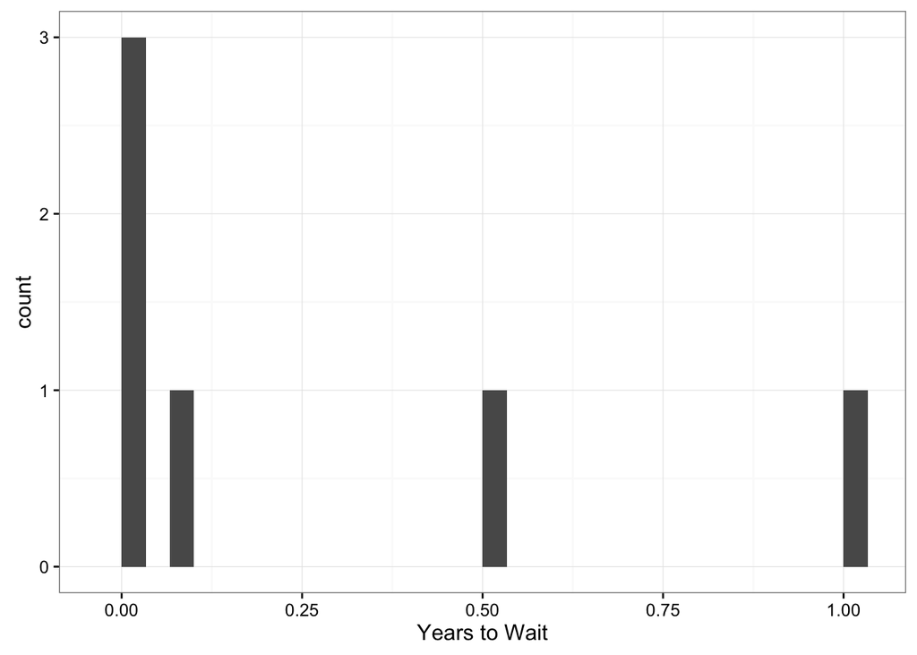

```r
#Histogram of years to wait
qplot(delaytimetot, data = d) +
  xlab("Years to Wait")
```

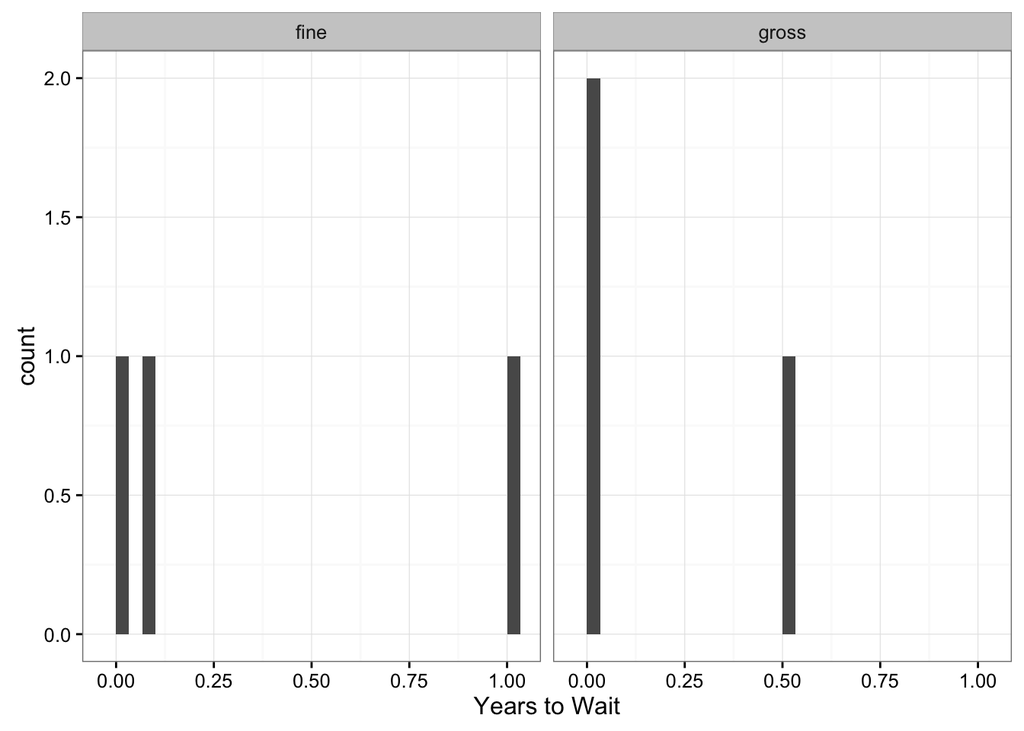

```r
#Histogram of years to wait by time metric condition
qplot(delaytimetot, data = d) +
  facet_wrap(~timeMetric) +
  xlab("Years to Wait")
```

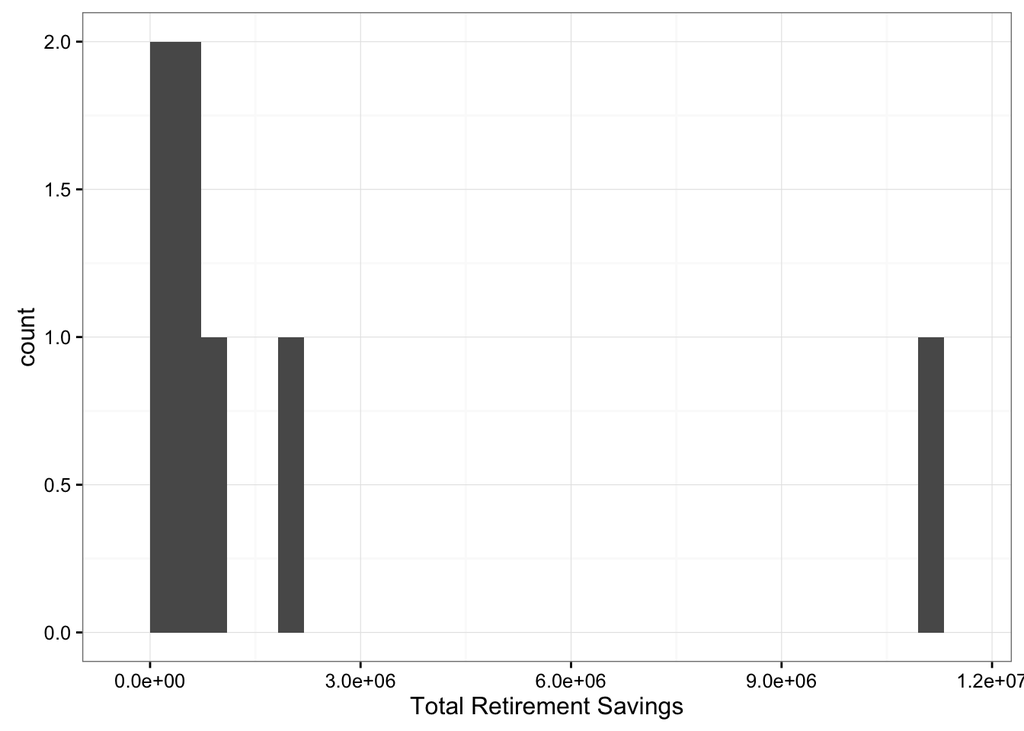

```r
#Histogram of total retirement savings
qplot(savingtot, data = d) +
  xlab("Total Retirement Savings")
```

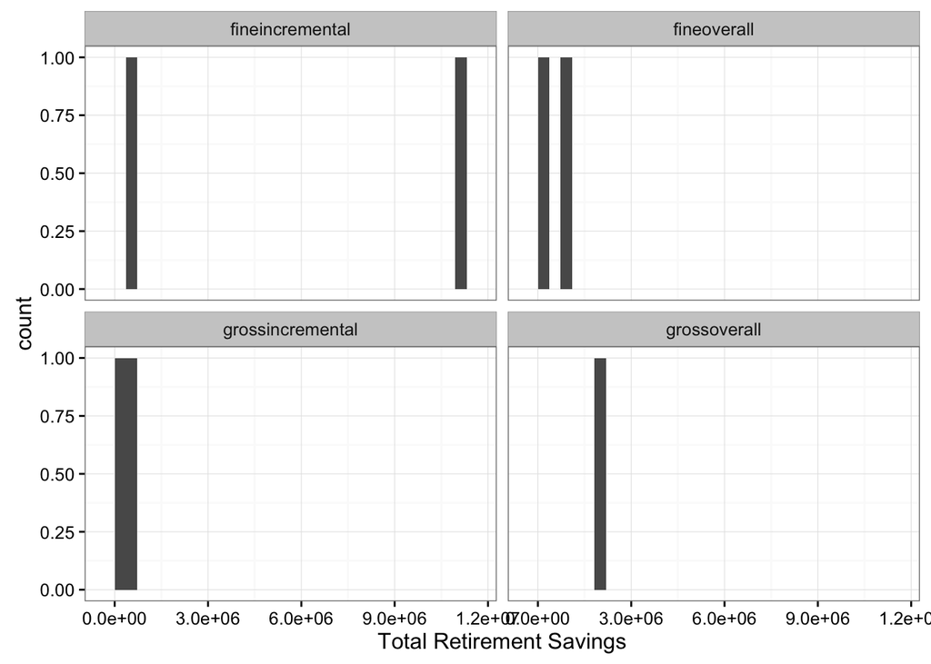

```r
#Histogram of total retirement savings by condition
qplot(savingtot, data = d) +
  facet_wrap(~condition) +
  xlab("Total Retirement Savings")
```

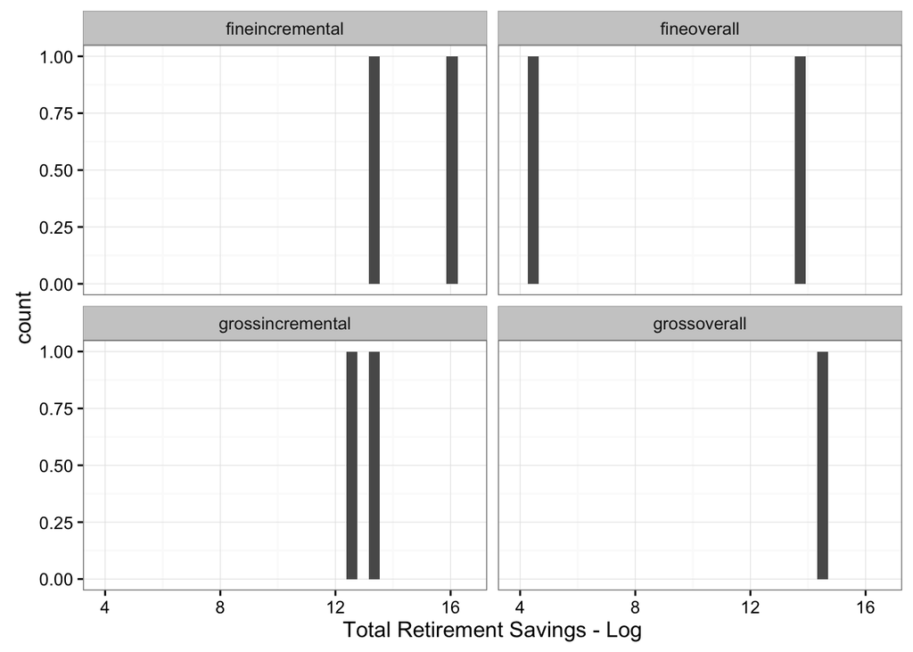

```r
#Histogram of log(total savings) by condition
qplot(logsavingtot, data = d) +
  facet_wrap(~condition) +
  xlab("Total Retirement Savings - Log")
```

#### Boxplots to identify outliers

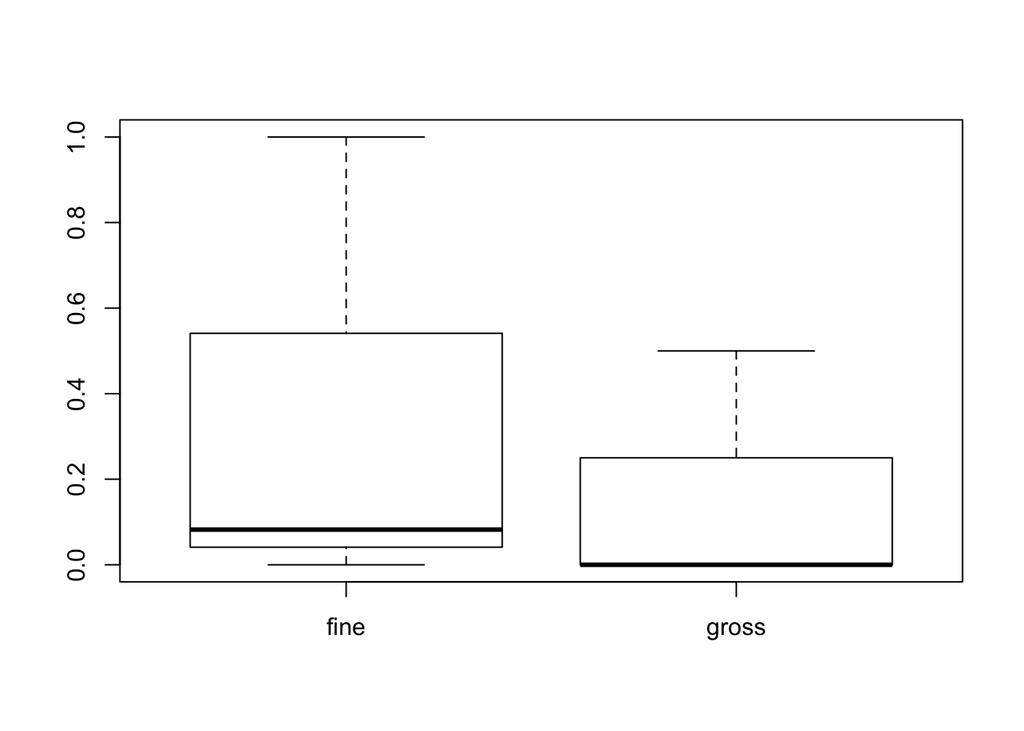

```r
delay1 = boxplot(delaytimetot ~ timeMetric, d) #When to save by time metric condition
```

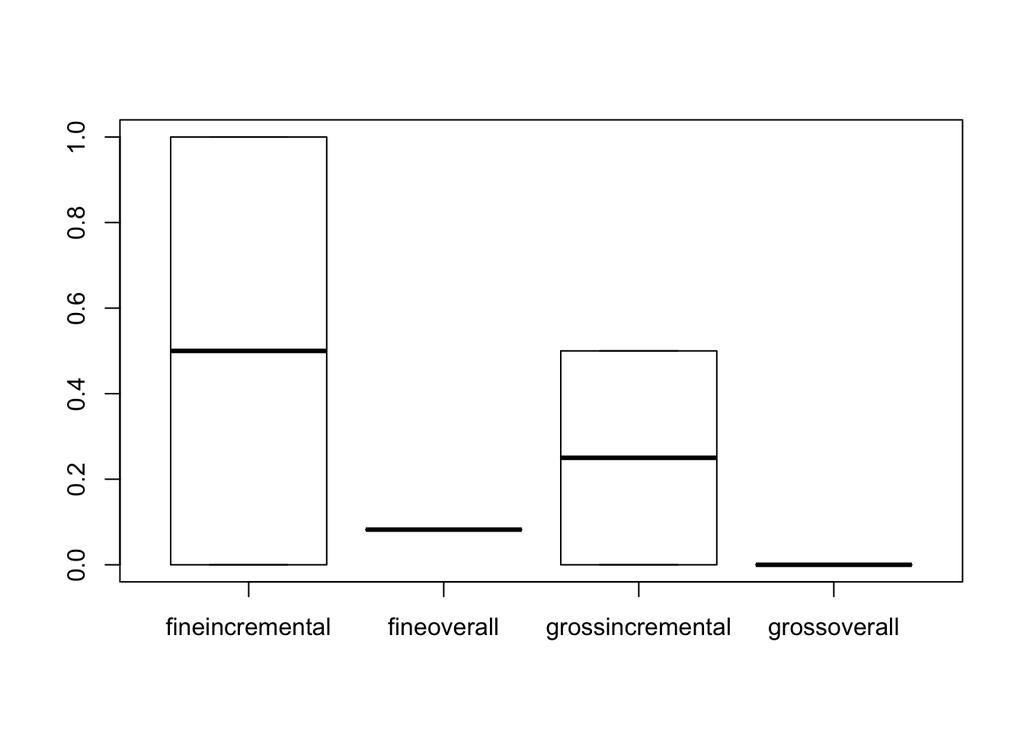

```r
#delay1 #will print outliers, if they exist
#delay1b = boxplot(delaytimetot[-c(83, 33)] ~ timeMetric[-c(83, 33)], d) #Removing outliers if necessary

delay2 = boxplot(delaytimetot ~ condition, d) #When to save across all 4 conditions
```

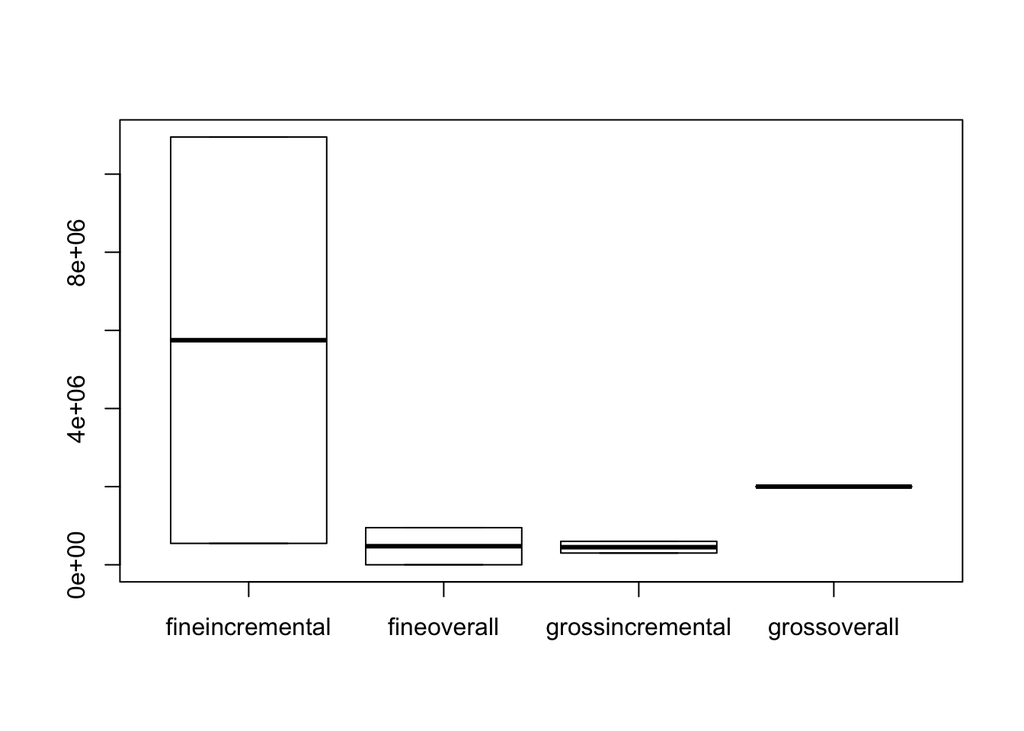

```r
#delay2 #print outliers

saving1 = boxplot(savingtot ~ condition, d) #How much to save across all 4 conditions
```

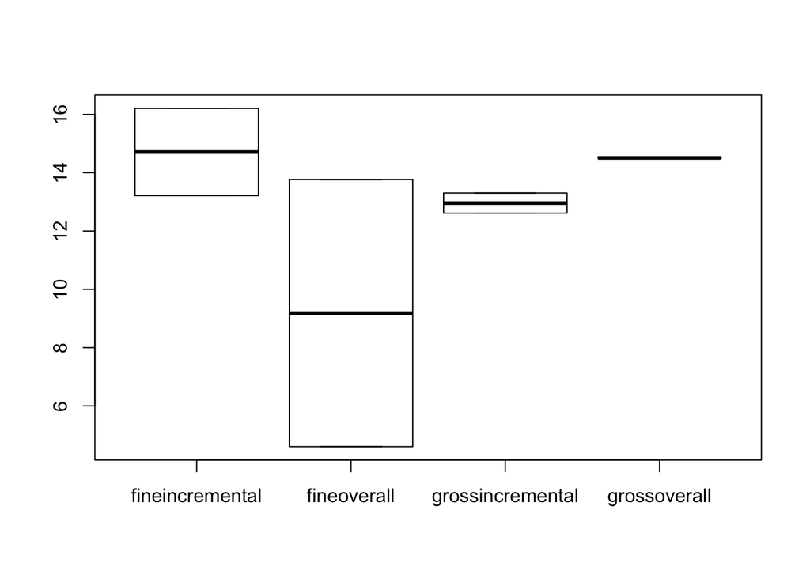

```r
#saving1 #print outliers
saving2 = boxplot(logsavingtot ~ condition, d) #How much to save (log) across all 4 conditions
```

```r
#saving2 #print outliers
```

### Exclusion Criteria

- Did not respond to a DV or gave uninterpretable response
- Gave responses mean+3SD for WHEN to save (as per original paper)
- Gave responses mean+3SD for HOW MUCH to save
- Would wait > 10950 in fine-grained condition
- Would wait > 30 years in gross-grained condition

Exclude people here.

### Sanity check

Now that we have excluded any invalid responses, the range of values for raw delaytime variable should be 1, 10,950 for fine-grained and 1, 30 for gross-grained. You can’t have said that you’ll wait longer to begin to save than is indicated in prompt.

```r
range(d$delaytime[d$timeMetric == "fine"], na.rm = T) #can't wait more than 10950 days
```

```
## [1]   0 365
```

```r
range(d$delaytime[d$timeMetric == "gross"], na.rm = T) #can't wait more than 30yrs
```

```
## [1] 0.0 0.5
```

Also expect that the mean(raw delaytime) for fine-grained condition should be larger than (or equal to) mean(raw delaytime) for gross-grained condition

```r
delayt = t.test(delaytime ~ timeMetric, d) #expect a significant difference
```

t = 1.12, p = 0.38

### Randomization check

There should be NO effect of incremental action condition on time/delay to save because that variable was not into play until after the delay question was answered

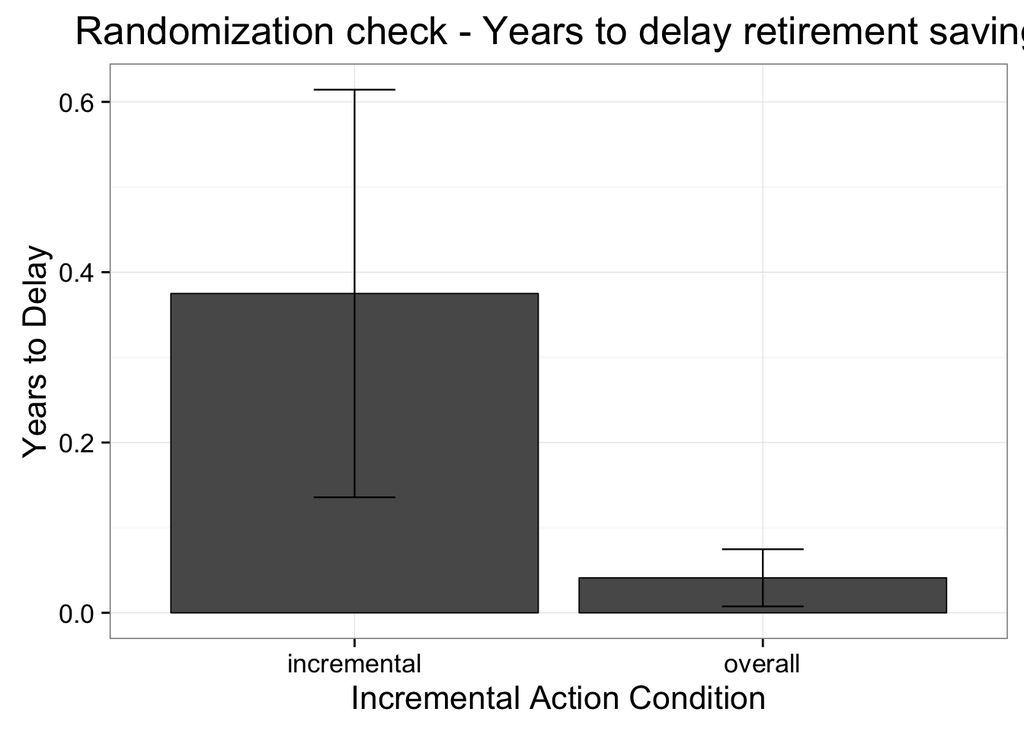

```r
delaytimemean2 = d %>%
  group_by(incrAction) %>%
  summarise(mean=mean(delaytimetot, na.rm = T), sd=sd(delaytimetot, na.rm = T), n = sum(!is.na(delaytimetot)), sem = sem(delaytimetot))
#delaytimemean2

ggplot(delaytimemean2, aes(x=incrAction, y = mean)) +
  geom_bar(position=position_dodge(), stat="identity",
           colour="black", # Use black outlines,
           size=.3) +
  geom_errorbar(aes(ymin=mean-sem, ymax=mean+sem),
                size=.4,
                width=.2,                    # Width of the error bars
                position=position_dodge(.9)) +
  xlab("Incremental Action Condition") +
  ylab("Years to Delay") +
  ggtitle("Randomization check - Years to delay retirement saving") +
  theme_bw(base_size = 16)
```

```r
t.test(delaytimetot ~ incrAction, d)
```

```
##
##  Welch Two Sample t-test
##
## data:  delaytimetot by incrAction
## t = 1.3749, df = 3.1712, p-value = 0.2583
## alternative hypothesis: true difference in means is not equal to 0
## 95 percent confidence interval:
##  -0.4159038  1.0837120
## sample estimates:
## mean in group incremental     mean in group overall
##                0.37500000                0.04109589
```

### More Visualization - Bar plots

How long people delay by time metric condition

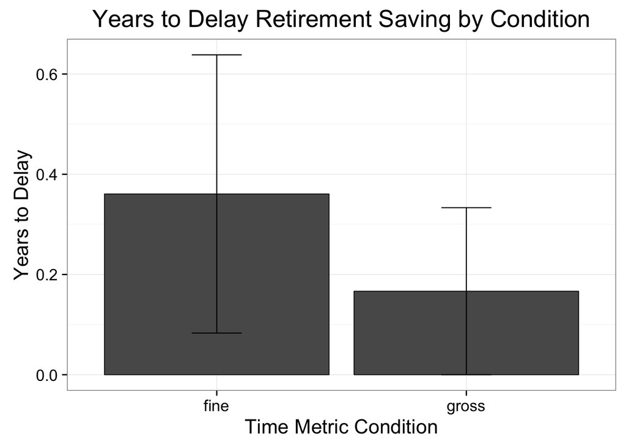

```r
delaytimemean = d %>%
  group_by(timeMetric) %>%
  summarise(mean=mean(delaytimetot, na.rm = T), sd=sd(delaytimetot, na.rm = T), n = sum(!is.na(delaytimetot)), sem = sem(delaytimetot))
#delaytimemean

ggplot(delaytimemean, aes(x=timeMetric, y = mean)) +
  geom_bar(position=position_dodge(), stat="identity",
           colour="black", # Use black outlines,
           size=.3) +
  geom_errorbar(aes(ymin=mean-sem, ymax=mean+sem),
                size=.4,
                width=.2,                    # Width of the error bars
                position=position_dodge(.9)) +
  xlab("Time Metric Condition") +
  ylab("Years to Delay") +
  ggtitle("Years to Delay Retirement Saving by Condition") +
  theme_bw(base_size = 16)
```

How much people should save by time metric and incremental action conditions

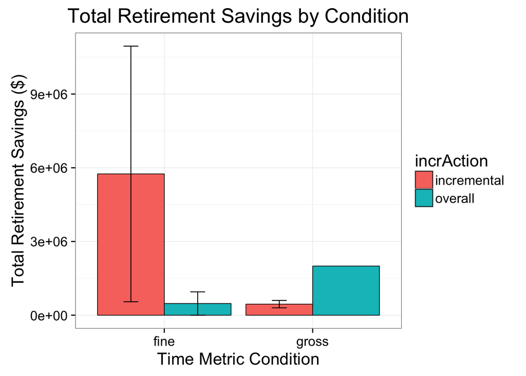

```r
savingtotmean = d %>%
  group_by(timeMetric, incrAction) %>%
  summarise(mean=mean(savingtot, na.rm = T), sd=sd(savingtot, na.rm = T), n = sum(!is.na(savingtot)), sem = sem(savingtot))
#savingtotmean

ggplot(savingtotmean, aes(x=timeMetric, y = mean, fill = incrAction)) +
  geom_bar(position=position_dodge(), stat="identity",
           colour="black", # Use black outlines,
           size=.3) +
  geom_errorbar(aes(ymin=mean-sem, ymax=mean+sem),
                size=.4,
                width=.2,                    # Width of the error bars
                position=position_dodge(.9)) +
  xlab("Time Metric Condition") +
  ylab("Total Retirement Savings ($)") +
  ggtitle("Total Retirement Savings by Condition") +
  theme_bw(base_size = 16)
```

How much people should save (log transformed) by time metric and incremental action conditions

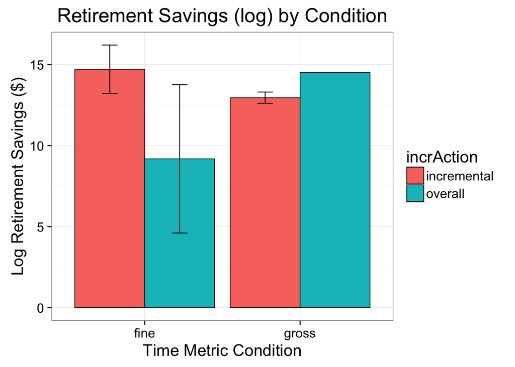

```r
logsavingtotmean = d %>%
  group_by(timeMetric, incrAction) %>%
  summarise(mean=mean(logsavingtot, na.rm = T), sd=sd(logsavingtot, na.rm = T), n = sum(!is.na(logsavingtot)), sem = sem(logsavingtot))
#logsavingtotmean

ggplot(logsavingtotmean, aes(x=timeMetric, y = mean, fill = incrAction)) +
  geom_bar(position=position_dodge(), stat="identity",
           colour="black", # Use black outlines,
           size=.3) +
  geom_errorbar(aes(ymin=mean-sem, ymax=mean+sem),
                size=.4,
                width=.2,                    # Width of the error bars
                position=position_dodge(.9)) +
  xlab("Time Metric Condition") +
  ylab("Log Retirement Savings ($)") +
  ggtitle("Retirement Savings (log) by Condition") +
  theme_bw(base_size = 16)
```

## Planned Analyses

#### Covariates

In the original paper, age, income, and education were not significantly correlated with WHEN to save, but income was positively correlated with AMOUNT to save. For both DVs, the authors ran regressions controlling for these 3 covariates, and not controlling for them, and interpretation of results was unchanged with demographic controls.

Relationship between demographics and WHEN to save:

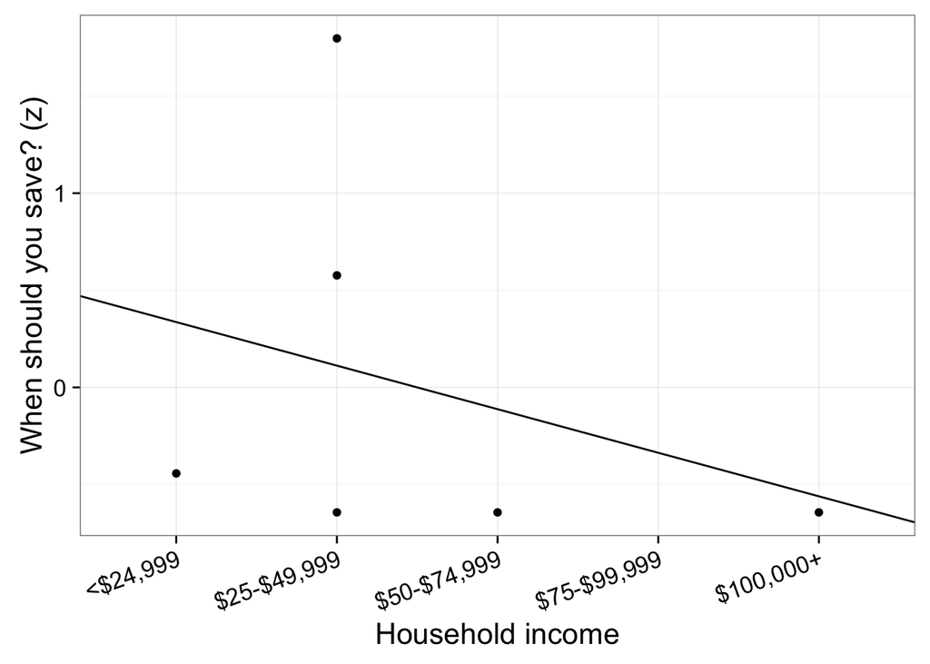

```r
d$age.s = scale(d$age)
#mean(d$age.s, na.rm = T); sd(d$age.s, na.rm = T)

# When to save
d$delaytimetot.s = scale(d$delaytimetot)
#mean(d$delaytimetot.s, na.rm = T); sd(d$delaytimetot.s, na.rm = T)

rslm.incdelay = lm(delaytimetot.s ~ income, d)
#rslm.incdelay$coefficients
ggplot(d, aes(incomecat, delaytimetot.s)) +
  geom_point(aes()) +
  geom_abline(intercept = rslm.incdelay$coefficients[1], slope = rslm.incdelay$coefficients[2]) +
  xlab("Household income") +
  ylab("When should you save? (z)") +
  theme_bw(base_size = 16) +
  theme(axis.text.x = element_text(angle = 20, hjust = 1))
```

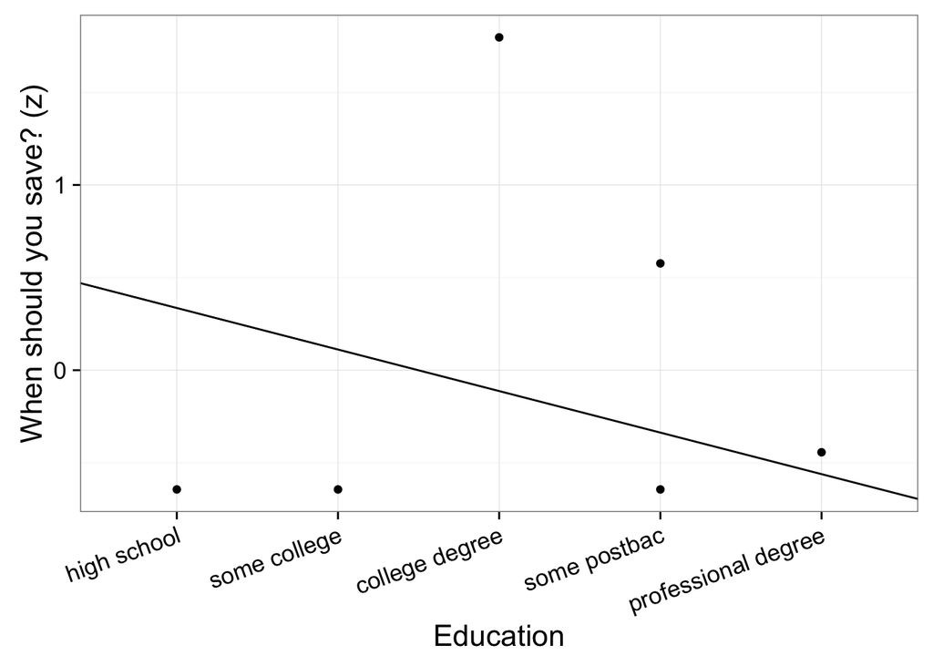

```r
rslm.edudelay = lm(delaytimetot.s ~ income, d)
#rslm.edudelay$coefficients
ggplot(d, aes(educat, delaytimetot.s)) +
  geom_point(aes()) +
  geom_abline(intercept = rslm.edudelay$coefficients[1], slope = rslm.edudelay$coefficients[2]) +
  xlab("Education") +
  ylab("When should you save? (z)") +
  theme_bw(base_size = 16) +
  theme(axis.text.x = element_text(angle = 20, hjust = 1))
```

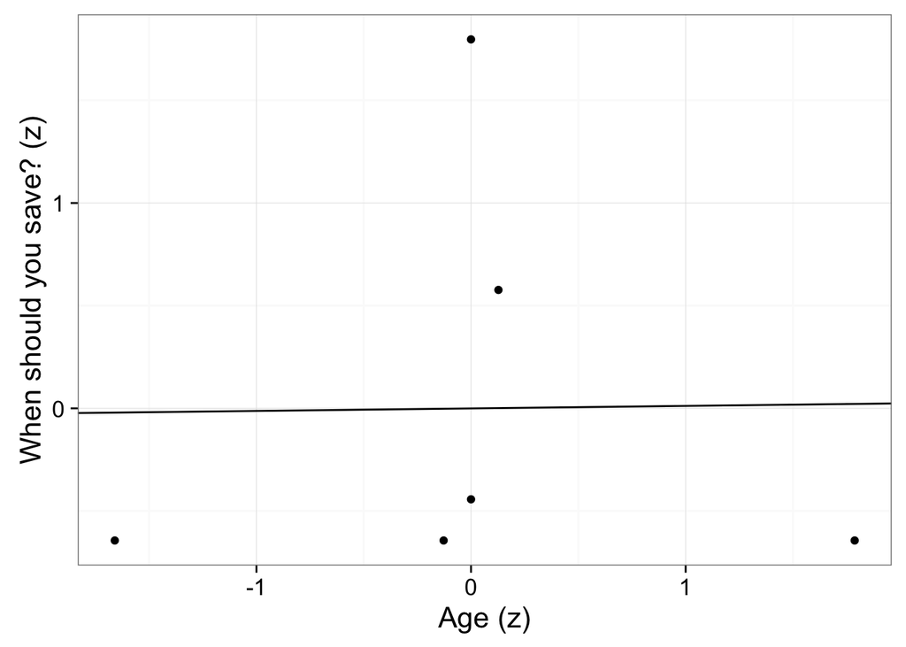

```r
rslm.agedelay = lm(delaytimetot.s ~ age.s, d)
#rslm.agedelay$coefficients
ggplot(d, aes(age.s, delaytimetot.s)) +
  geom_point(aes()) +
  geom_abline(intercept = rslm.agedelay$coefficients[1], slope = rslm.agedelay$coefficients[2]) +
  xlab("Age (z)") +
  ylab("When should you save? (z)") +
  theme_bw(base_size = 16)
```

Relationship between demographics and HOW MUCH to save:

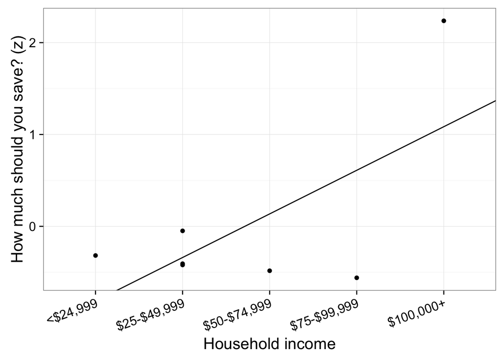

```r
d$savingtot.s = scale(d$savingtot, scale = T)
#mean(d$savingtot.s, na.rm = T); sd(d$savingtot.s, na.rm = T)

rslm.incsaving = lm(savingtot.s ~ income, d) # Relationship in original paper
#rslm.incsaving$coefficients
ggplot(d, aes(incomecat, savingtot.s)) +
  geom_point(aes()) +
  geom_abline(intercept = rslm.incsaving$coefficients[1], slope = rslm.incsaving$coefficients[2]) +
  xlab("Household income") +
  ylab("How much should you save? (z)") +
  theme_bw(base_size = 16) +
  theme(axis.text.x = element_text(angle = 20, hjust = 1))
```

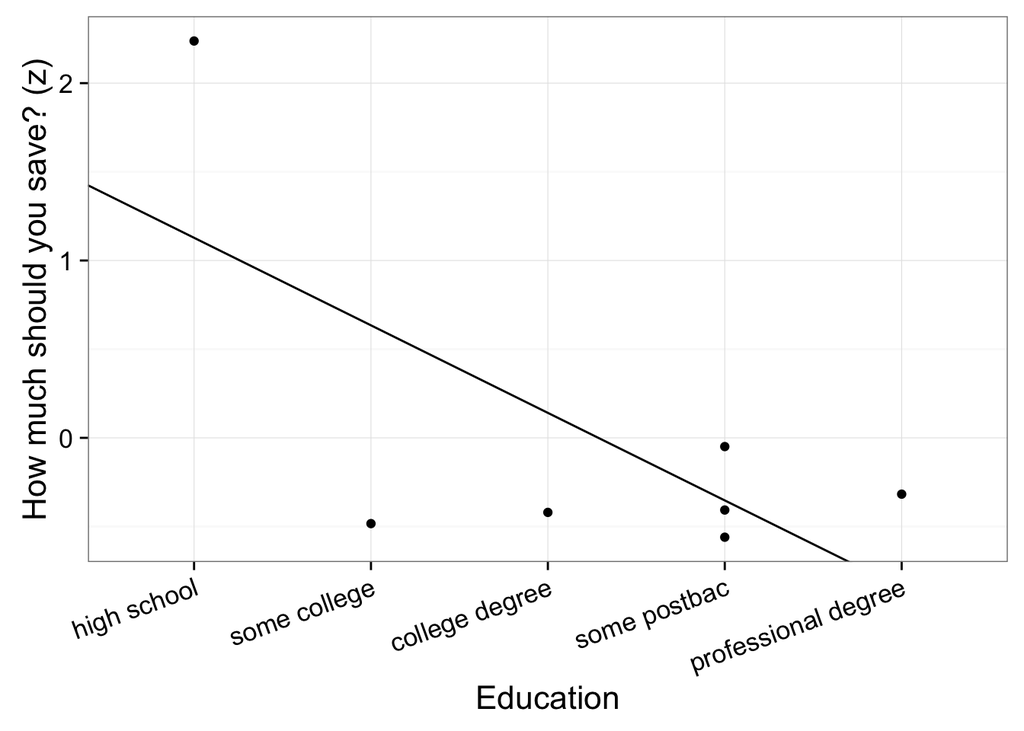

```r
rslm.edusaving = lm(savingtot.s ~ edu, d)
#rslm.edusaving$coefficients
ggplot(d, aes(educat, savingtot.s)) +
  geom_point(aes()) +
  geom_abline(intercept = rslm.edusaving$coefficients[1], slope = rslm.edusaving$coefficients[2]) +
  xlab("Education") +
  ylab("How much should you save? (z)") +
  theme_bw(base_size = 16) +
  theme(axis.text.x = element_text(angle = 20, hjust = 1))
```

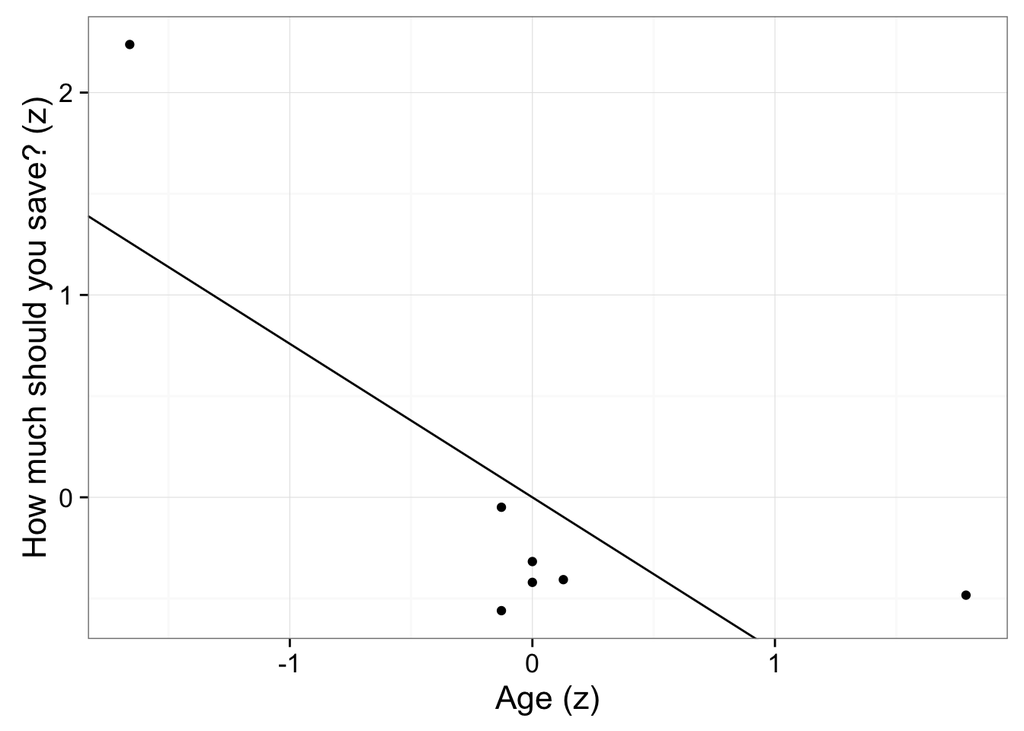

```r
rslm.agesaving = lm(savingtot.s ~ age.s, d)
#rslm.agesaving$coefficients
ggplot(d, aes(age.s, savingtot.s)) +
  geom_point(aes()) +
  geom_abline(intercept = rslm.agesaving$coefficients[1], slope = rslm.agesaving$coefficients[2]) +
  xlab("Age (z)") +
  ylab("How much should you save? (z)") +
  theme_bw(base_size = 16)
```

#### Examining correlations among variables.

```r
cor(d[, c("conditionnum", "age", "gender", "income", "edu", "race", "delaytimetot", "savingtot", "delay.rt", "savings.rt")])
```

```
##              conditionnum         age gender     income         edu race
## conditionnum    1.0000000  0.49727518     NA -0.3721042  0.37210420   NA
## age             0.4972752  1.00000000     NA -0.4163359  0.16961834   NA
## gender                 NA          NA      1         NA          NA   NA
## income         -0.3721042 -0.41633592     NA  1.0000000 -0.73750000   NA
## edu             0.3721042  0.16961834     NA -0.7375000  1.00000000   NA
## race                   NA          NA     NA         NA          NA    1
## delaytimetot           NA          NA     NA         NA          NA   NA
## savingtot      -0.4203202 -0.75881665     NA  0.6553007 -0.68144473   NA
## delay.rt       -0.4553588 -0.05920762     NA -0.2490699 -0.22515999   NA
## savings.rt      0.5966246  0.52425075     NA -0.3038171 -0.09332777   NA
##              delaytimetot    savingtot     delay.rt  savings.rt
## conditionnum           NA -0.420320237 -0.455358755  0.59662462
## age                    NA -0.758816652 -0.059207621  0.52425075
## gender                 NA           NA           NA          NA
## income                 NA  0.655300739 -0.249069889 -0.30381714
## edu                    NA -0.681444727 -0.225159991 -0.09332777
## race                   NA           NA           NA          NA
## delaytimetot            1           NA           NA          NA
## savingtot              NA  1.000000000 -0.006555863 -0.29280913
## delay.rt               NA -0.006555863  1.000000000  0.23917677
## savings.rt             NA -0.292809132  0.239176774  1.00000000
```

```r
cov(d[, c("delaytimetot", "savingtot")]) #covariance between when to save and how much
```

```
##              delaytimetot    savingtot
## delaytimetot           NA           NA
## savingtot              NA 1.531749e+13
```

```r
#d0 = na.omit(d)
#cor(d0[, c("conditionnum", "age", "gender", "income", "edu", "race", "delaytimetot", "savingtot", "delay.rt", "savings.rt")])
#cov(d0[, c("delaytimetot", "savingtot")])
```

Note significant correlations.

### Main analyses

There were two main analyses in the original paper. The first was whether there were differences between time metric condition on WHEN to begin saving for retirement. The second was whether there were differences between time metric conditions or incremental action conditions on how much to save. In both cases, the authors ran a regression with no demographic controls, and a model with demographic controls (age, education, income). Only income significantly predicted amount to save, but controlling for demographics did not change the interpretation of either outcome.

#### Effect of time metric and incremental action on when to save

```r
rs.lmdelaytot = lm(delaytimetot ~ timeMetric * incrAction, d); summary(rs.lmdelaytot) #no demographic controls
```

```
##
## Call:
## lm(formula = delaytimetot ~ timeMetric * incrAction, data = d)
##
## Residuals:
##          1          2          3          5          6          7
##  5.000e-01  2.500e-01  2.776e-17  5.551e-17 -5.000e-01 -2.500e-01
##
## Coefficients:
##                                   Estimate Std. Error t value Pr(>|t|)
## (Intercept)                         0.5000     0.3953   1.265    0.333
## timeMetricgross                    -0.2500     0.5590  -0.447    0.698
## incrActionoverall                  -0.4178     0.6847  -0.610    0.604
## timeMetricgross:incrActionoverall   0.1678     0.9682   0.173    0.878
##
## Residual standard error: 0.559 on 2 degrees of freedom
##   (1 observation deleted due to missingness)
## Multiple R-squared:  0.2555, Adjusted R-squared:  -0.8612
## F-statistic: 0.2288 on 3 and 2 DF,  p-value: 0.8708
```

```r
anova(rs.lmdelaytot)
```

```
## Analysis of Variance Table
##
## Response: delaytimetot
##                       Df  Sum Sq  Mean Sq F value Pr(>F)
## timeMetric             1 0.05649 0.056491  0.1808 0.7121
## incrAction             1 0.14866 0.148656  0.4757 0.5617
## timeMetric:incrAction  1 0.00939 0.009387  0.0300 0.8784
## Residuals              2 0.62500 0.312500
```

```r
rs.lmdelaytot.cov = lm(delaytimetot ~ timeMetric * incrAction + age + edu + income, d); summary(rs.lmdelaytot.cov)
```

```
##
## Call:
## lm(formula = delaytimetot ~ timeMetric * incrAction + age + edu +
##     income, data = d)
##
## Residuals:
## ALL 6 residuals are 0: no residual degrees of freedom!
##
## Coefficients: (1 not defined because of singularities)
##                                   Estimate Std. Error t value Pr(>|t|)
## (Intercept)                        6.69304         NA      NA       NA
## timeMetricgross                    0.23162         NA      NA       NA
## incrActionoverall                 -0.62237         NA      NA       NA
## age                               -0.06119         NA      NA       NA
## edu                               -0.67043         NA      NA       NA
## income                            -1.04543         NA      NA       NA
## timeMetricgross:incrActionoverall       NA         NA      NA       NA
##
## Residual standard error: NaN on 0 degrees of freedom
##   (1 observation deleted due to missingness)
## Multiple R-squared:      1,  Adjusted R-squared:    NaN
## F-statistic:   NaN on 5 and 0 DF,  p-value: NA
```

```r
#controlling for demographics
```

In the original paper, there was only a main effect of time metric such that people in the fine-grained condition would begin to save sooner than those in the gross-grained condition.

### Effect of time metric and incremental action on how much to save (log transformed)

It was unclear why savings were log transformed in the original paper, but I will run my first analysis on savings amount as the original authors did.

```r
rs.lmlogsavingstot = lm(logsavingtot ~ timeMetric * incrAction, d); summary(rs.lmlogsavingstot) #no demographic controls
```

```
##
## Call:
## lm(formula = logsavingtot ~ timeMetric * incrAction, data = d)
##
## Residuals:
##          1          2          3          4          5          6
## -1.498e+00  3.466e-01 -9.437e-16 -4.580e+00  4.580e+00  1.498e+00
##          7
## -3.466e-01
##
## Coefficients:
##                                   Estimate Std. Error t value Pr(>|t|)
## (Intercept)                         14.711      2.789   5.275   0.0133 *
## timeMetricgross                     -1.753      3.944  -0.444   0.6868
## incrActionoverall                   -5.526      3.944  -1.401   0.2557
## timeMetricgross:incrActionoverall    7.077      6.236   1.135   0.3389
## ---
## Signif. codes:  0 '***' 0.001 '**' 0.01 '*' 0.05 '.' 0.1 ' ' 1
##
## Residual standard error: 3.944 on 3 degrees of freedom
## Multiple R-squared:  0.4364, Adjusted R-squared:  -0.1272
## F-statistic: 0.7744 on 3 and 3 DF,  p-value: 0.5807
```

```r
anova(rs.lmlogsavingstot)
```

```
## Analysis of Variance Table
##
## Response: logsavingtot
##                       Df Sum Sq Mean Sq F value Pr(>F)
## timeMetric             1  3.998  3.9979  0.2570 0.6471
## incrAction             1 12.110 12.1100  0.7784 0.4426
## timeMetric:incrAction  1 20.033 20.0326  1.2877 0.3389
## Residuals              3 46.672 15.5572
```

```r
rs.lmlogsavingstot.cov = lm(logsavingtot ~ timeMetric * incrAction + age + edu + income, d); summary(rs.lmlogsavingstot.cov) #controlling for demographics
```

```
##
## Call:
## lm(formula = logsavingtot ~ timeMetric * incrAction + age + edu +
##     income, data = d)
##
## Residuals:
## ALL 7 residuals are 0: no residual degrees of freedom!
##
## Coefficients:
##                                   Estimate Std. Error t value Pr(>|t|)
## (Intercept)                        54.5797         NA      NA       NA
## timeMetricgross                     6.3400         NA      NA       NA
## incrActionoverall                   6.8382         NA      NA       NA
## age                                -0.5369         NA      NA       NA
## edu                                -5.7115         NA      NA       NA
## income                             -5.1358         NA      NA       NA
## timeMetricgross:incrActionoverall  -6.7081         NA      NA       NA
##
## Residual standard error: NaN on 0 degrees of freedom
## Multiple R-squared:      1,  Adjusted R-squared:    NaN
## F-statistic:   NaN on 6 and 0 DF,  p-value: NA
```

In the original paper, there were no significant effects (ps > .14).

#### Effect of time metric and incremental action on how much to save

I will also run a regression on the original savings amount.

```r
rs.lmsavingstot = lm(savingtot ~ timeMetric * incrAction, d); summary(rs.lmsavingstot) #no demographic controls
```

```
##
## Call:
## lm(formula = savingtot ~ timeMetric * incrAction, data = d)
##
## Residuals:
##          1          2          3          4          5          6
## -5.201e+06  1.500e+05  4.657e-10 -4.750e+05  4.749e+05  5.201e+06
##          7
## -1.500e+05
##
## Coefficients:
##                                   Estimate Std. Error t value Pr(>|t|)
## (Intercept)                        5748750    3016680   1.906    0.153
## timeMetricgross                   -5298750    4266230  -1.242    0.302
## incrActionoverall                 -5273700    4266230  -1.236    0.304
## timeMetricgross:incrActionoverall  6823700    6745502   1.012    0.386
##
## Residual standard error: 4266000 on 3 degrees of freedom
## Multiple R-squared:  0.4059, Adjusted R-squared:  -0.1882
## F-statistic: 0.6832 on 3 and 3 DF,  p-value: 0.6191
```

```r
anova(rs.lmsavingstot)
```

```
## Analysis of Variance Table
##
## Response: savingtot
##                       Df     Sum Sq    Mean Sq F value Pr(>F)
## timeMetric             1 7.8892e+12 7.8892e+12  0.4335 0.5573
## incrAction             1 1.0788e+13 1.0788e+13  0.5927 0.4974
## timeMetric:incrAction  1 1.8625e+13 1.8625e+13  1.0233 0.3862
## Residuals              3 5.4602e+13 1.8201e+13
```

```r
rs.lmsavingstot.cov = lm(savingtot ~ timeMetric * incrAction + age + edu + income, d); summary(rs.lmsavingstot.cov) #controlling for demographics
```

```
##
## Call:
## lm(formula = savingtot ~ timeMetric * incrAction + age + edu +
##     income, data = d)
##
## Residuals:
## ALL 7 residuals are 0: no residual degrees of freedom!
##
## Coefficients:
##                                   Estimate Std. Error t value Pr(>|t|)
## (Intercept)                       32976136         NA      NA       NA
## timeMetricgross                    5166569         NA      NA       NA
## incrActionoverall                  7475073         NA      NA       NA
## age                                -567121         NA      NA       NA
## edu                               -4546948         NA      NA       NA
## income                            -2021323         NA      NA       NA
## timeMetricgross:incrActionoverall -7209315         NA      NA       NA
##
## Residual standard error: NaN on 0 degrees of freedom
## Multiple R-squared:      1,  Adjusted R-squared:    NaN
## F-statistic:   NaN on 6 and 0 DF,  p-value: NA
```

### Comparing means from my sample to means in original paper

Determining how similar my means are to those in the original paper.

**Means of when to start saving**

Mean years to delay in fine-grained condition = 0.45 years

```r
t.test(d$delaytimetot[d$timeMetric == "fine"], mu = .45) #comparing to mean(fine) in original study
```

```
##
##  One Sample t-test
##
## data:  d$delaytimetot[d$timeMetric == "fine"]
## t = -0.27852, df = 2, p-value = 0.8068
## alternative hypothesis: true mean is not equal to 0.45
## 95 percent confidence interval:
##  -1.018330  1.739792
## sample estimates:
## mean of x
## 0.3607306
```

Mean years to delay in gross-grained condition = 1.70 years

```r
t.test(d$delaytimetot[d$timeMetric == "gross"], mu = 1.70) #comparing to mean(gross) in original study
```

```
##
##  One Sample t-test
##
## data:  d$delaytimetot[d$timeMetric == "gross"]
## t = -9.2, df = 2, p-value = 0.01161
## alternative hypothesis: true mean is not equal to 1.7
## 95 percent confidence interval:
##  -0.5504421  0.8837755
## sample estimates:
## mean of x
## 0.1666667
```

**Means of how much to save**

Mean amount to save in fine, incremental condition = $224,134, log = 12.32

```r
t.test(d$logsavingtot[d$timeMetric == "fine" & d$incrAction == "incremental"], mu = 12.32)
```

```
##
##  One Sample t-test
##
## data:  d$logsavingtot[d$timeMetric == "fine" & d$incrAction == "incremental"]
## t = 1.5963, df = 1, p-value = 0.3563
## alternative hypothesis: true mean is not equal to 12.32
## 95 percent confidence interval:
##  -4.32121 33.74318
## sample estimates:
## mean of x
##  14.71098
```

```r
t.test(d$savingtot[d$timeMetric == "fine" & d$incrAction == "incremental"], mu = 224134)
```

```
##
##  One Sample t-test
##
## data:  d$savingtot[d$timeMetric == "fine" & d$incrAction == "incremental"]
## t = 1.0622, df = 1, p-value = 0.4808
## alternative hypothesis: true mean is not equal to 224134
## 95 percent confidence interval:
##  -60339397  71836897
## sample estimates:
## mean of x
##   5748750
```

Mean amount to save in fine, overall condition = $215,345, log = 12.28

```r
t.test(d$logsavingtot[d$timeMetric == "fine" & d$incrAction == "overall"], mu = 12.28)
```

```
##
##  One Sample t-test
##
## data:  d$logsavingtot[d$timeMetric == "fine" & d$incrAction == "overall"]
## t = -0.6759, df = 1, p-value = 0.6216
## alternative hypothesis: true mean is not equal to 12.28
## 95 percent confidence interval:
##  -49.00367  67.37306
## sample estimates:
## mean of x
##  9.184694
```

```r
t.test(d$savingtot[d$timeMetric == "fine" & d$incrAction == "overall"], mu = 215345)
```

```
##
##  One Sample t-test
##
## data:  d$savingtot[d$timeMetric == "fine" & d$incrAction == "overall"]
## t = 0.5468, df = 1, p-value = 0.6814
## alternative hypothesis: true mean is not equal to 215345
## 95 percent confidence interval:
##  -5559762  6509862
## sample estimates:
## mean of x
##    475050
```

Mean amount to save in gross, incremental condition = $240,385, log = 12.39

```r
t.test(d$logsavingtot[d$timeMetric == "gross" & d$incrAction == "incremental"], mu = 12.39)
```

```
##
##  One Sample t-test
##
## data:  d$logsavingtot[d$timeMetric == "gross" & d$incrAction == "incremental"]
## t = 1.6392, df = 1, p-value = 0.3487
## alternative hypothesis: true mean is not equal to 12.39
## 95 percent confidence interval:
##   8.554476 17.361746
## sample estimates:
## mean of x
##  12.95811
```

```r
t.test(d$savingtot[d$timeMetric == "gross" & d$incrAction == "incremental"], mu = 240385)
```

```
##
##  One Sample t-test
##
## data:  d$savingtot[d$timeMetric == "gross" & d$incrAction == "incremental"]
## t = 1.3974, df = 1, p-value = 0.3954
## alternative hypothesis: true mean is not equal to 240385
## 95 percent confidence interval:
##  -1455931  2355931
## sample estimates:
## mean of x
##    450000
```

Mean amount to save in gross, overall condition = $451,350, log = 13.02

```r
#t.test(d$logsavingtot[d$timeMetric == "gross" & d$incrAction == "overall"], mu = 13.02)
#t.test(d$logsavingtot[d$timeMetric == "gross" & d$incrAction == "overall"], mu = 451350)
```

## Exploratory analyses

**Investigating the correlation between delaying to save and total savings**

If I think I need to save a lot, perhaps I feel that I should get started sooner, rather than wait (negative correlation).

```r
#cor.test(d$savingtot.s, d$delaytimetot.s)
d0 = na.omit(d)
#cor.test(d0$savingtot.s, d0$delaytimetot.s)
#cov(d0[, c("delaytimetot.s", "savingtot.s")])

rslm.delaysaving = lm(savingtot.s ~ delaytimetot.s, d); summary(rslm.delaysaving)
```

```
##
## Call:
## lm(formula = savingtot.s ~ delaytimetot.s, data = d)
##
## Residuals:
##       1       2       3       5       6       7
##  0.1858 -0.2758 -0.3931 -0.5833  1.8937 -0.8274
## attr(,"scaled:center")
## [1] 2192514
## attr(,"scaled:scale")
## [1] 3913756
##
## Coefficients:
##                Estimate Std. Error t value Pr(>|t|)
## (Intercept)     0.09336    0.45075   0.207    0.846
## delaytimetot.s -0.38929    0.49377  -0.788    0.475
##
## Residual standard error: 1.104 on 4 degrees of freedom
##   (1 observation deleted due to missingness)
## Multiple R-squared:  0.1345, Adjusted R-squared:  -0.08188
## F-statistic: 0.6216 on 1 and 4 DF,  p-value: 0.4746
```

```r
rslm.delaysaving$coefficients
```

```
##    (Intercept) delaytimetot.s
##      0.0933636     -0.3892871
```

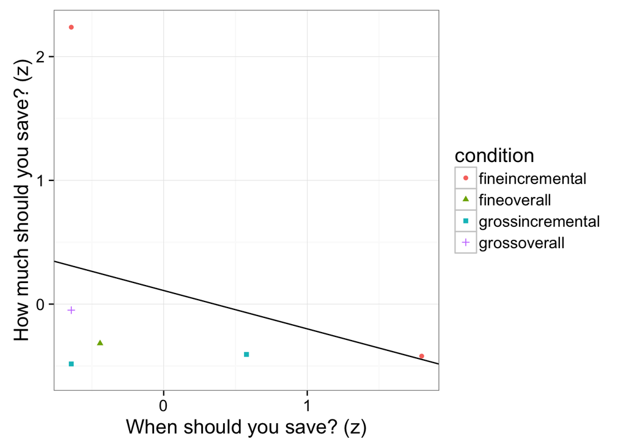

```r
ggplot(d, aes(delaytimetot.s, savingtot.s)) +
  geom_point(aes(shape = condition, color = condition)) +
  geom_abline(intercept = 0.11, slope = -0.31) +
  xlab("When should you save? (z)") +
  ylab("How much should you save? (z)") +
  theme_bw(base_size = 16)
```

Exploring any demographic differences (e.g., gender or race) or other interesting findings that came out from analyses above.

Examining whether there is any role of RT - were questions easier to answer in gross overall, or fine overall conditions?

### Next steps

Should we replicate the original results, or even partially replicate, I would love to explore mediators. A later study in the original paper concluded that fine-grained time metrics don’t make the future feel nearer. Instead, it makes people feel more connected to their future self. However, the future self measure was confounded with time metric, so I’d like to find an independent way to measure it.